# Severe Weather Events of Greatest Impact

jmtaysom

April 23, 2015

## Severe Weather Events of Greatest Impact

Synopsis: This project examines NOAA’s storm database in an attempt to analyze the storms and identify those with the greatest impact. There are two categories that will be the main focus: greatest property damage and most harmful to human health. As seen in the results Tornadoes harm the most people while flooding and huricanes do the most property damage.

## Data Processing

Load the appropriate libraries.

```r
library(ggplot2)
library(reshape2)
library(plyr)
```

Download and open the storm dataset.

```r
setwd("~/datasciencecoursera/ReproducibleResearch")
url = 'https://d396qusza40orc.cloudfront.net/repdata%2Fdata%2FStormData.csv.bz2'
zip = 'Storm_Data.csv.bz2'
#download.file(url, zip, method='curl')
rm(url)
storm <- read.csv(bzfile(zip))
rm(zip)
```

Calculate the total damagein billions of dollars by converting the character descriptions of the magnitude of damage into numeric and then applying it to the value of the damage.

```r
storm$PROPDMGEXP <-revalue(storm$PROPDMGEXP, c("K"="1000", "M"="1000000", "B"="1000000000"))
storm$PROPDMGEXP <- sub("^$", "1", storm$PROPDMGEXP)
storm$PROPDMG <- storm$PROPDMG * as.numeric(storm$PROPDMGEXP) / 1000000000
```

```r
human.damage <- ddply(storm, "EVTYPE", summarize, injuries = sum(INJURIES), fatalities = sum(FATALITIES))
hd.m <- melt(human.damage, id.vars='EVTYPE')
hd.m <- hd.m[complete.cases(hd.m),]
top.hd <- tail(arrange(hd.m, value), n=6)
top.hd
```

```
##              EVTYPE   variable value
## 1965      LIGHTNING   injuries  5230
## 1966        TORNADO fatalities  5633
## 1967 EXCESSIVE HEAT   injuries  6525
## 1968          FLOOD   injuries  6789
## 1969      TSTM WIND   injuries  6957
## 1970        TORNADO   injuries 91346
```

Sumarize the total damage by event type and select the top three which happen to do an order of magnitude more damage than the next few.

```r
prop.damage <- ddply(storm, "EVTYPE", summarize, propdmg = sum(PROPDMG))
prop.damage <- prop.damage[complete.cases(prop.damage),]
top.prop <-tail(arrange(prop.damage, propdmg), n=3)
```

## Results

Tornadoes are by far the greatest threat to human health. Tornado fatalities rank 5th in the most people effected by weather and there are more than 10 times the number of injuries from tornadoes as any other other weather event.

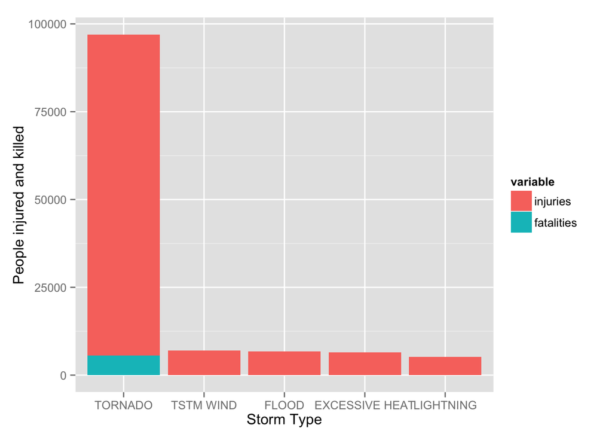

```r
ggplot(top.hd, aes(reorder(x=EVTYPE, -value), y=value,fill=variable)) + geom_bar(stat='identity') + labs(x="Storm Type", y="People injured and killed")
```

Floods and huricanes are the weather events that do the most property damage. The top three property damaging weather events do an order of magnitude more damage than any of the other events.

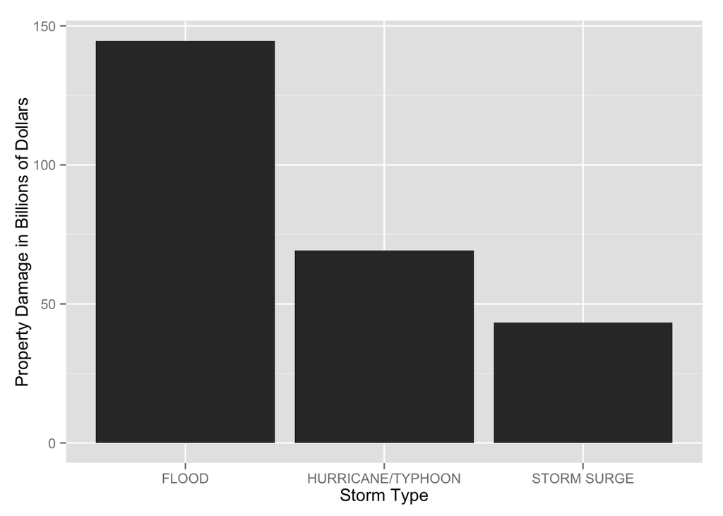

```r
ggplot(top.prop, aes(x=EVTYPE, y=propdmg)) + geom_bar(stat='identity') + labs(x="Storm Type", y="Property Damage in Billions of Dollars")
```